# Simulations for `norm_aic_sim.R`

# System setup

```r
R <- list.files(path = "./simulations/R", pattern = "*.R", full.names = TRUE)
sapply(R, source, .GlobalEnv)
library(knitr)
library(kableExtra)
```

# Setting

## Data

Following Wang *et al.* (2012) with one-hundred replications, the correlated normal responses are generated from the model
$$y_{ij} = \mathbf{X}_{ij}^{\top}\boldsymbol{\beta}
+ \varepsilon_{ij},$$
where $i = 1, \ldots, 200,$ $j = 1, \ldots, 4,$ $\mathbf{X}_{ij} = (x_{ij, 1}, \ldots, x_{ij, 6})^{\top},$ and $\boldsymbol{\beta} = (2.0, 3.0, 0.5, 0.0, 0.0, 0.0)^{\top}.$

- For the covariates,
  - $x_{ij,1}$ was generated from the Bernoulli(0.5) distribution, and
  - $x_{ij,2}$ to $x_{ij,6}$ from the multivariate normal distribution with mean 0 and an AR(1) covariance matrix with marginal variance 1 and auto-correlation coefficient 0.5.
- The random errors $(\varepsilon_{i1}, \ldots, \varepsilon_{i4})^{\top}$ are generated from the multivariate normal distribution with marginal mean 0, marginal variance 1, and a correlation coefficient of 0. Thus, the observations are independent of each other.

## Best subsets

All $2^6 - 1 = 63$ subsets of the full saturated model were fit. Then, the models resulting in the minimum AIC and QIC values were selected as the best fitting models.

```r
nsims <- 100L
beta <- c(2.0, 3.0, 0.5, 0.0, 0.0, 0.0)
w <- which(beta != 0)
l <- length(w)
```

# Results

The simulations results are stored in:

```r
load("./simulations/outputs/norm_aic_sim/norm_aic_sim.RData")
```

and provide a baseline comparison between AIC and QIC.

## Information criterions across the simulations

Now for each of the models with the minimum AIC and QIC, the information criteria values will be broken into their parts to see what is impacting the selection process. Additionally, this provides a look at the stability of the information criterions across the simulations. These results also examine the relationship between the likelihood and quasi-likelihood framework.

### IC

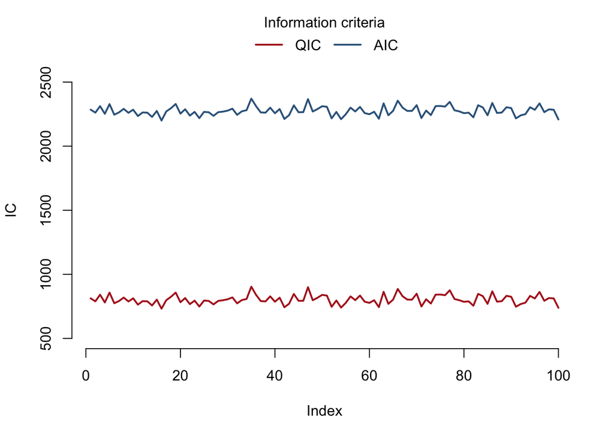

```r
a <- sapply(res_aic, function(x) {x$ic_min}, simplify = TRUE)
q <- sapply(res_qic, function(x) {x$ic_min}, simplify = TRUE)

plot(
    x = seq_len(nsims), y = q,
    ylim = c(500, 2500),
    xlab = "Index", ylab = "IC",
    lwd = 2, type = "l", col = "firebrick",
    bty = "n"
)
lines(
    x = seq_len(nsims), y = a,
    lwd = 2, col = "steelblue4"
)
legend_top(
    legend = c("QIC", "AIC"),
    col = c("firebrick", "steelblue4"),
    lwd = 2, lty = 1, title = "Information criteria"
)
```

### GOF

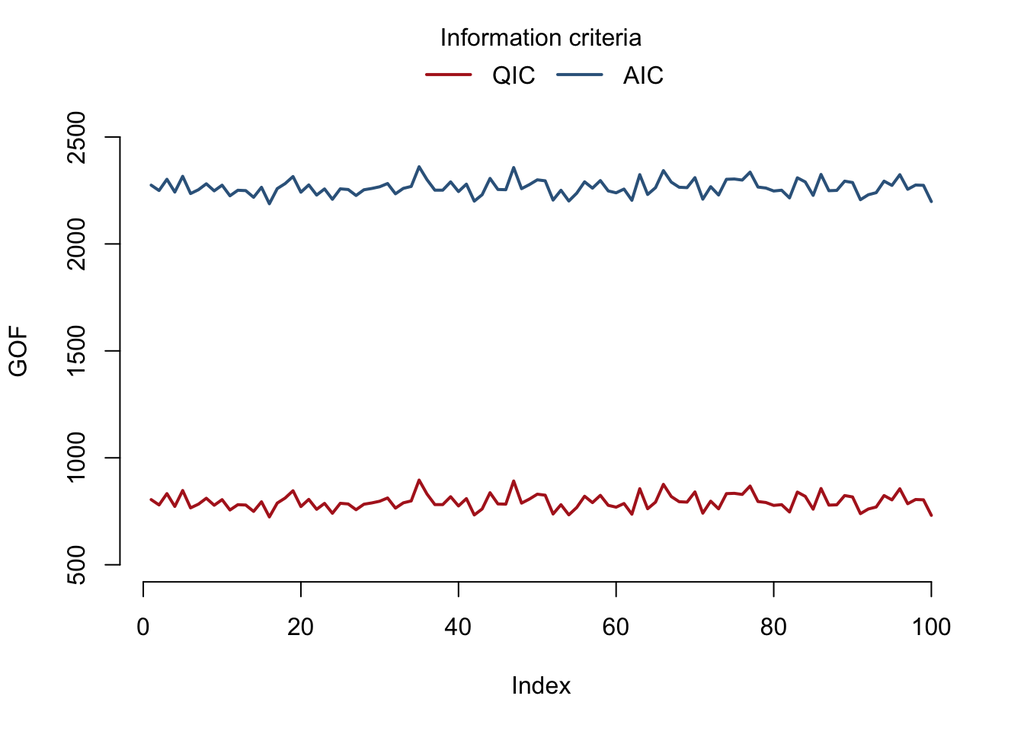

```r
gf_q <- rep(NA, nsims)
gf_a <- rep(NA, nsims)
for (k in seq_len(nsims)) {
    w_q <- res_qic[[k]]$min
    w_a <- res_aic[[k]]$min
    gf_q[k] <- res_qic[[k]]$gof[w_q]
    gf_a[k] <- res_aic[[k]]$gof[w_a]
}

plot(
    x = seq_len(nsims), y = gf_q,
    ylim = c(500, 2500),
    xlab = "Index", ylab = "GOF",
    type = "l", lwd = 2, col = "firebrick",
    bty = "n"
)
lines(
    x = seq_len(nsims), y = gf_a,
    col = "steelblue4", lwd = 2
)
legend_top(
    legend = c("QIC", "AIC"),
    col = c("firebrick", "steelblue4"),
    lwd = 2, lty = 1, title = "Information criteria"
)
```

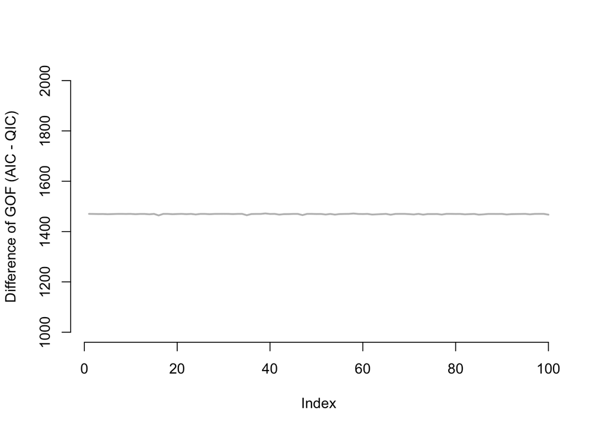

```r
plot(
    x =  seq_len(nsims), y = gf_a - gf_q,
    ylim = c(1000, 2000),
    xlab = "Index", ylab = "Difference of GOF (AIC - QIC)",
    type = "l", lwd = 2, col = "gray",
    bty = "n"
)
```

### Penalty

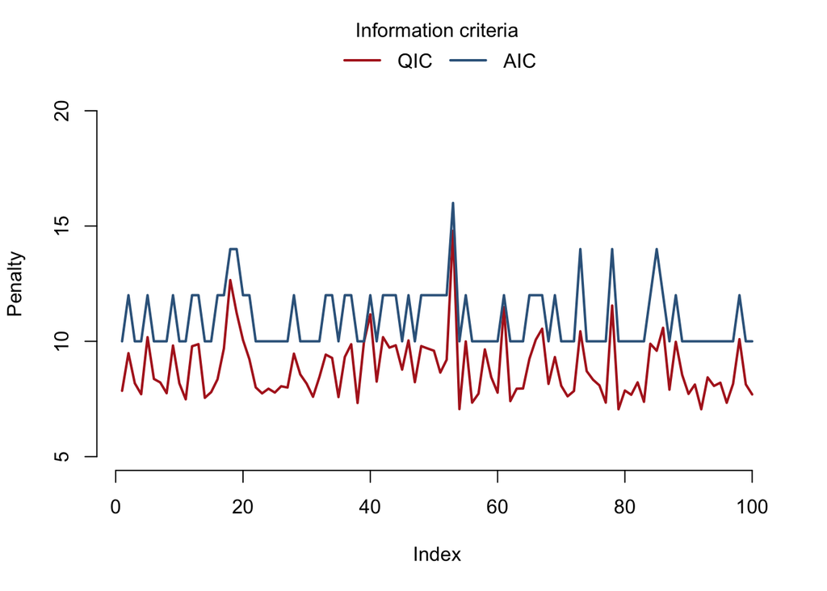

```r
pen_q <- rep(NA, nsims)
pen_a <- rep(NA, nsims)
for (k in seq_len(nsims)) {
    w_q <- res_qic[[k]]$min
    w_a <- res_aic[[k]]$min
    pen_q[k] <- res_qic[[k]]$penalty[w_q]
    pen_a[k] <- res_aic[[k]]$penalty[w_a]
}

plot(
    x = seq_len(nsims), y = pen_q,
    ylim = c(5, 20),
    xlab = "Index", ylab = "Penalty",
    type = "l", lwd = 2, col = "firebrick",
    bty = "n"
)
lines(
    x = seq_len(nsims), y = pen_a,
    col = "steelblue4", lwd = 2
)
legend_top(
    legend = c("QIC", "AIC"),
    col = c("firebrick", "steelblue4"),
    lwd = 2, lty = 1, title = "Information criteria"
)
```

## Feature selection based on AIC and QIC

For measuring the overall performance based on each information criterion, a function will be created called `look` that reports the number of models, where

- the number of features selected is less than the number of non-zero coefficients in the generating model (`under`),
- only the non-zero features from the generating model were selected (`exact`),
- the number of features selected matches the number of non-zero coefficients in the generating model; however, at least one of the selected features is NOT one of the non-zero effects in the generating model (i.e., `mis`),
- the number of features selected is greated than the number of non-zero coefficients in the generating model (`over`), and
- the number of features selected is greated than the number of non-zero coefficients in the generating model and include all the non-zero effects (`over_inc`).

```r
# creating a function to generate a look at the simulation results
look <- function(x) {
    under <- 0
    exact <- 0
    mis <- 0
    over <- 0
    over_inc <- 0
    for (k in seq_len(nsims)) {
        under <- under + (length(x[[k]]$vars) < l)
        exact <- exact + identical(x[[k]]$vars, w)
        mis <- mis + (!identical(x[[k]]$vars, w) & (length(x[[k]]$vars) == l))
        over <- over + (length(x[[k]]$vars) > l)
        over_inc <- over_inc + ((length(x[[k]]$vars) > l) & all(w %in% x[[k]]$vars))
    }
    return(
        data.frame(
            under = under, exact = exact,
            mis = mis, over = over,
            over_inc = over_inc
        )
    )
}
```

Using the `look` function, we have the following summary measures from the simulation set, where the model resulting in the minimum AIC and QIC values were selected as the best fitting models for each information criterion.

```r
data.frame(
    ic = c("AIC", "QIC"),
    dplyr::bind_rows(look(res_aic), look(res_qic))
)
```

```
##    ic under exact mis over over_inc
## 1 AIC     0    60   0   40       40
## 2 QIC     0    59   0   41       41
```